# 2019 NFL QB Statistics

2019 NFL QB Statistics Josh Drummond 02/05/2020

## Overview

An activity to provide an opportunity to practice building simple linear regression models using R, with the added opportunity to finetune R Markdown, Git and GitHub skills.

## The Data

This data has been sources from Pro Football Reference

## Our Question

Passer rating is a metric used to evaluate quarterbacks in the NFL, and it is calculated based on a quarterback’s completions, yards gained, touchdowns, interceptions and attempts.

*How does passer rating relate to success?* We can use the number of wins a team has when a particular quarterback tarts as a meausre of success. And then the questons we are trying to answer now are:

*1. Do quarterbacks with a higher passer rating have more wins?*

*2. Do quarterbacks with a lower passer rating have fewer wins?*

*3. How many wins can we expect to get when we have a tarting quarterback with a particular passer rating?*

### *Creating new repository on GitHub*

The new repository can be found on my [GitHub](https://github.com/JCDrummond/qb_model_data)

### *Cloning GitHub repository to a local repository on my computer*

Following these steps in terminal, I was able to set up my working directory to complete this project

- $ mkdir data
- $ cd data
- $ git remote add origin https://github.com/JCDrummond/qb_model_data.git
- $ git clone https://github.com/JCDrummond/qb_model_data.git

## Load required packages

```r
library(tidyverse)
library(broom)
library(knitr)
```

## Read data

Read in the file using the `read_csv()` function from the `readr` package.

```r
df <- read_csv("2019_nfl_qb_data-1.csv")
```

```r
str(df)
```

```
## Classes 'spec_tbl_df', 'tbl_df', 'tbl' and 'data.frame': 55 obs. of  23 variables:
##  $ case_no         : num  1 2 3 4 5 6 7 8 9 10 ...
##  $ player_name     : chr  "Jared Goff" "Jameis Winston" "Matt Ryan" "Tom Brady" ...
##  $ player_id       : chr  "GoffJa00" "WinsJa00" "RyanMa00" "BradTo00" ...
##  $ team            : chr  "LAR" "TAM" "ATL" "NWE" ...
##  $ age             : num  25 25 34 42 27 26 38 36 22 24 ...
##  $ position        : chr  "QB" "QB" "QB" "QB" ...
##  $ games_played    : num  16 16 15 16 16 16 16 16 16 16 ...
##  $ games_started   : num  16 16 15 16 16 16 16 16 16 16 ...
##  $ wins            : num  9 7 7 12 9 8 5 13 5 6 ...
##  $ losses          : num  7 9 8 4 7 8 11 3 10 10 ...
##  $ draws           : num  0 0 0 0 0 0 0 0 1 0 ...
##  $ completions     : num  394 380 408 373 388 388 390 353 349 317 ...
##  $ attempts        : num  626 626 616 613 607 596 591 569 542 534 ...
##  $ cmp_pc          : num  62.9 60.7 66.2 60.8 63.9 65.1 66 62 64.4 59.4 ...
##  $ yards           : num  4638 5109 4466 4057 4039 ...
##  $ touchdowns      : num  22 33 26 24 27 30 23 26 20 22 ...
##  $ touchdown_pc    : num  3.5 5.3 4.2 3.9 4.4 5 3.9 4.6 3.7 4.1 ...
##  $ interceptions   : num  16 30 14 8 7 11 20 4 12 21 ...
##  $ interceptions_pc: num  2.6 4.8 2.3 1.3 1.2 1.8 3.4 0.7 2.2 3.9 ...
##  $ passer_rating   : num  86.5 84.3 92.1 88 93.1 99.7 88.5 95.4 87.4 78.8 ...
##  $ sacks           : num  22 47 48 27 37 23 34 36 48 40 ...
##  $ yards_lost      : num  170 282 316 185 230 151 222 284 309 285 ...
##  $ sack_pc         : num  3.4 7 7.2 4.2 5.7 3.7 5.4 6 8.1 7 ...
##  - attr(*, "spec")=
##   .. cols(
##   ..   case_no = col_double(),
##   ..   player_name = col_character(),
##   ..   player_id = col_character(),
##   ..   team = col_character(),
##   ..   age = col_double(),
##   ..   position = col_character(),
##   ..   games_played = col_double(),
##   ..   games_started = col_double(),
##   ..   wins = col_double(),
##   ..   losses = col_double(),
##   ..   draws = col_double(),
##   ..   completions = col_double(),
##   ..   attempts = col_double(),
##   ..   cmp_pc = col_double(),
##   ..   yards = col_double(),
##   ..   touchdowns = col_double(),
##   ..   touchdown_pc = col_double(),
##   ..   interceptions = col_double(),
##   ..   interceptions_pc = col_double(),
##   ..   passer_rating = col_double(),
##   ..   sacks = col_double(),
##   ..   yards_lost = col_double(),
##   ..   sack_pc = col_double()
##   .. )
```

## Checking the data

Check the first 6 rows of the data file using `head()`

```r
head(df)
```

```
## # A tibble: 6 x 23
##   case_no player_name player_id team    age position games_played games_started
##     <dbl> <chr>       <chr>     <chr> <dbl> <chr>           <dbl>         <dbl>
## 1       1 Jared Goff  GoffJa00  LAR      25 QB                 16            16
## 2       2 Jameis Win… WinsJa00  TAM      25 QB                 16            16
## 3       3 Matt Ryan   RyanMa00  ATL      34 QB                 15            15
## 4       4 Tom Brady   BradTo00  NWE      42 QB                 16            16
## 5       5 Carson Wen… WentCa00  PHI      27 QB                 16            16
## 6       6 Dak Presco… PresDa01  DAL      26 QB                 16            16
## # … with 15 more variables: wins <dbl>, losses <dbl>, draws <dbl>,
## #   completions <dbl>, attempts <dbl>, cmp_pc <dbl>, yards <dbl>,
## #   touchdowns <dbl>, touchdown_pc <dbl>, interceptions <dbl>,
## #   interceptions_pc <dbl>, passer_rating <dbl>, sacks <dbl>, yards_lost <dbl>,
## #   sack_pc <dbl>
```

Check the last 6 rows of the data file using `tail()`

```r
tail(df)
```

```
## # A tibble: 6 x 23
##   case_no player_name player_id team    age position games_played games_started
##     <dbl> <chr>       <chr>     <chr> <dbl> <chr>           <dbl>         <dbl>
## 1      50 Chase Dani… DaniCh00  CHI      33 qb                  3             1
## 2      51 Ben Roethl… RoetBe00  PIT      37 qb                  2             2
## 3      52 Will Grier  GrieWi00  CAR      24 qb                  2             2
## 4      53 Robert Gri… GrifRo01  BAL      29 qb                  7             1
## 5      54 A.J. McCar… McCaA.00  HOU      29 qb                  2             1
## 6      55 Colt McCoy  McCoCo00  WAS      33 qb                  1             1
## # … with 15 more variables: wins <dbl>, losses <dbl>, draws <dbl>,
## #   completions <dbl>, attempts <dbl>, cmp_pc <dbl>, yards <dbl>,
## #   touchdowns <dbl>, touchdown_pc <dbl>, interceptions <dbl>,
## #   interceptions_pc <dbl>, passer_rating <dbl>, sacks <dbl>, yards_lost <dbl>,
## #   sack_pc <dbl>
```

## Data Transformation

```r
filter_df <- df %>%
  filter(games_started >= 10) %>%
  mutate(win_percentage = wins / games_started *100)
```

```r
knitr::kable(filter_df)
```

| case_no | player_name | player_id | team | age | position | games_played | games_started | wins | losses | draws | completions | attempts | cmp_pc | yards | touchdowns | touchdown_pc | interceptions | interceptions_pc | passer_rating | sacks | yards_lost | sack_pc | win_percentage |
| --- | --- | --- | --- | --- | --- | --- | --- | --- | --- | --- | --- | --- | --- | --- | --- | --- | --- | --- | --- | --- | --- | --- | --- |
| 1 | Jared Goff | GoffJa00 | LAR | 25 | QB | 16 | 16 | 9 | 7 | 0 | 394 | 626 | 62.9 | 4638 | 22 | 3.5 | 16 | 2.6 | 86.5 | 22 | 170 | 3.4 | 56.25000 |
| 2 | Jameis Winston | WinsJa00 | TAM | 25 | QB | 16 | 16 | 7 | 9 | 0 | 380 | 626 | 60.7 | 5109 | 33 | 5.3 | 30 | 4.8 | 84.3 | 47 | 282 | 7.0 | 43.75000 |
| 3 | Matt Ryan | RyanMa00 | ATL | 34 | QB | 15 | 15 | 7 | 8 | 0 | 408 | 616 | 66.2 | 4466 | 26 | 4.2 | 14 | 2.3 | 92.1 | 48 | 316 | 7.2 | 46.66667 |
| 4 | Tom Brady | BradTo00 | NWE | 42 | QB | 16 | 16 | 12 | 4 | 0 | 373 | 613 | 60.8 | 4057 | 24 | 3.9 | 8 | 1.3 | 88.0 | 27 | 185 | 4.2 | 75.00000 |
| 5 | Carson Wentz | WentCa00 | PHI | 27 | QB | 16 | 16 | 9 | 7 | 0 | 388 | 607 | 63.9 | 4039 | 27 | 4.4 | 7 | 1.2 | 93.1 | 37 | 230 | 5.7 | 56.25000 |
| 6 | Dak Prescott | PresDa01 | DAL | 26 | QB | 16 | 16 | 8 | 8 | 0 | 388 | 596 | 65.1 | 4902 | 30 | 5.0 | 11 | 1.8 | 99.7 | 23 | 151 | 3.7 | 50.00000 |
| 7 | Philip Rivers | RivePh00 | LAC | 38 | QB | 16 | 16 | 5 | 11 | 0 | 390 | 591 | 66.0 | 4615 | 23 | 3.9 | 20 | 3.4 | 88.5 | 34 | 222 | 5.4 | 31.25000 |
| 8 | Aaron Rodgers | RodgAa00 | GNB | 36 | QB | 16 | 16 | 13 | 3 | 0 | 353 | 569 | 62.0 | 4002 | 26 | 4.6 | 4 | 0.7 | 95.4 | 36 | 284 | 6.0 | 81.25000 |
| 9 | Kyler Murray | MurrKy00 | ARI | 22 | QB | 16 | 16 | 5 | 10 | 1 | 349 | 542 | 64.4 | 3722 | 20 | 3.7 | 12 | 2.2 | 87.4 | 48 | 309 | 8.1 | 31.25000 |
| 10 | Baker Mayfield | MayfBa00 | CLE | 24 | QB | 16 | 16 | 6 | 10 | 0 | 317 | 534 | 59.4 | 3827 | 22 | 4.1 | 21 | 3.9 | 78.8 | 40 | 285 | 7.0 | 37.50000 |
| 11 | Andy Dalton | DaltAn00 | CIN | 32 | QB | 13 | 13 | 2 | 11 | 0 | 314 | 528 | 59.5 | 3494 | 16 | 3.0 | 14 | 2.7 | 78.3 | 37 | 249 | 6.5 | 15.38462 |
| 12 | Mitchell Trubisky | TrubMi00 | CHI | 25 | QB | 15 | 15 | 8 | 7 | 0 | 326 | 516 | 63.2 | 3138 | 17 | 3.3 | 10 | 1.9 | 83.0 | 38 | 234 | 6.9 | 53.33333 |
| 13 | Russell Wilson | WilsRu00 | SEA | 31 | QB | 16 | 16 | 11 | 5 | 0 | 341 | 516 | 66.1 | 4110 | 31 | 6.0 | 5 | 1.0 | 106.3 | 48 | 319 | 8.5 | 68.75000 |
| 14 | Derek Carr | CarrDe02 | OAK | 28 | QB | 16 | 16 | 7 | 9 | 0 | 361 | 513 | 70.4 | 4054 | 21 | 4.1 | 8 | 1.6 | 100.8 | 29 | 184 | 5.4 | 43.75000 |
| 15 | Ryan Fitzpatrick | FitzRy00 | MIA | 37 | QB | 15 | 13 | 5 | 8 | 0 | 311 | 502 | 62.0 | 3529 | 20 | 4.0 | 13 | 2.6 | 85.5 | 40 | 209 | 7.4 | 38.46154 |
| 16 | Deshaun Watson | WatsDe00 | HOU | 24 | QB | 15 | 15 | 10 | 5 | 0 | 333 | 495 | 67.3 | 3852 | 26 | 5.3 | 12 | 2.4 | 98.0 | 44 | 257 | 8.2 | 66.66667 |
| 17 | Kyle Allen | AlleKy00 | CAR | 23 | QB | 13 | 12 | 5 | 7 | 0 | 303 | 489 | 62.0 | 3322 | 17 | 3.5 | 16 | 3.3 | 80.0 | 46 | 397 | 8.6 | 41.66667 |
| 18 | Patrick Mahomes | MahoPa00 | KAN | 24 | QB | 14 | 14 | 11 | 3 | 0 | 319 | 484 | 65.9 | 4031 | 26 | 5.4 | 5 | 1.0 | 105.3 | 17 | 127 | 3.4 | 78.57143 |
| 19 | Jimmy Garoppolo | GaroJi00 | SFO | 28 | QB | 16 | 16 | 13 | 3 | 0 | 329 | 476 | 69.1 | 3978 | 27 | 5.7 | 13 | 2.7 | 102.0 | 36 | 237 | 7.0 | 81.25000 |
| 20 | Gardner Minshew | MinsGa00 | JAX | 23 | QB | 14 | 12 | 6 | 6 | 0 | 285 | 470 | 60.6 | 3271 | 21 | 4.5 | 6 | 1.3 | 91.2 | 33 | 184 | 6.6 | 50.00000 |
| 21 | Josh Allen | AlleJo02 | BUF | 23 | QB | 16 | 16 | 10 | 6 | 0 | 271 | 461 | 58.8 | 3089 | 20 | 4.3 | 9 | 2.0 | 85.3 | 38 | 237 | 7.6 | 62.50000 |
| 22 | Daniel Jones | JoneDa05 | NYG | 22 | QB | 13 | 12 | 3 | 9 | 0 | 284 | 459 | 61.9 | 3027 | 24 | 5.2 | 12 | 2.6 | 87.7 | 38 | 295 | 7.6 | 25.00000 |
| 23 | Jacoby Brissett | BrisJa00 | IND | 27 | QB | 15 | 15 | 7 | 8 | 0 | 272 | 447 | 60.9 | 2942 | 18 | 4.0 | 6 | 1.3 | 88.0 | 27 | 159 | 5.7 | 46.66667 |
| 24 | Kirk Cousins | CousKi00 | MIN | 31 | QB | 15 | 15 | 10 | 5 | 0 | 307 | 444 | 69.1 | 3603 | 26 | 5.9 | 6 | 1.4 | 107.4 | 28 | 206 | 5.9 | 66.66667 |
| 25 | Sam Darnold | DarnSa00 | NYJ | 22 | QB | 13 | 13 | 7 | 6 | 0 | 273 | 441 | 61.9 | 3024 | 19 | 4.3 | 13 | 2.9 | 84.3 | 33 | 212 | 7.0 | 53.84615 |
| 26 | Lamar Jackson | JackLa00 | BAL | 22 | QB | 15 | 15 | 13 | 2 | 0 | 265 | 401 | 66.1 | 3127 | 36 | 9.0 | 6 | 1.5 | 113.3 | 23 | 106 | 5.4 | 86.66667 |
| 27 | Drew Brees | BreeDr00 | NOR | 40 | QB | 11 | 11 | 8 | 3 | 0 | 281 | 378 | 74.3 | 2979 | 27 | 7.1 | 4 | 1.1 | 116.3 | 12 | 89 | 3.1 | 72.72727 |
| 29 | Ryan Tannehill | TannRy00 | TEN | 31 | QB | 12 | 10 | 7 | 3 | 0 | 201 | 286 | 70.3 | 2742 | 22 | 7.7 | 6 | 2.1 | 117.5 | 31 | 212 | 9.8 | 70.00000 |

## Exploratory Data Analysis

Below I have created a plot to observe the relatonship between the “Win Percentage” and the “Passer Rating”

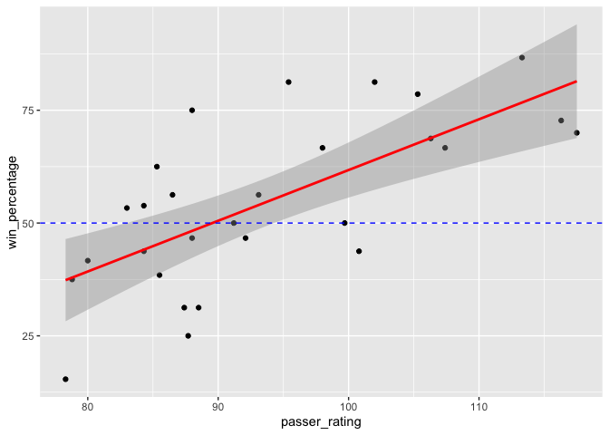

```r
ggplot(data = filter_df, aes(x = passer_rating, y = win_percentage)) +
  geom_point(colour = "black") +
  geom_smooth(method = "lm", colour = "red") +
  geom_hline(yintercept = 50, colour = "blue", linetype = "dashed")
```

As we can see from the graph above, there is a clear linear relationship between those two factors, which, we can explore the strength by the correlation coefficient.

```r
cor(x = filter_df$passer_rating, y = filter_df$win_percentage, method = "pearson")
```

```
## [1] 0.6863687
```

```r
summary(filter_df)
```

```
##     case_no      player_name         player_id             team
##  Min.   : 1.00   Length:28          Length:28          Length:28
##  1st Qu.: 7.75   Class :character   Class :character   Class :character
##  Median :14.50   Mode  :character   Mode  :character   Mode  :character
##  Mean   :14.54
##  3rd Qu.:21.25
##  Max.   :29.00
##       age          position          games_played   games_started
##  Min.   :22.00   Length:28          Min.   :11.00   Min.   :10.00
##  1st Qu.:23.75   Class :character   1st Qu.:14.00   1st Qu.:13.00
##  Median :26.50   Mode  :character   Median :15.00   Median :15.00
##  Mean   :28.29                      Mean   :14.86   Mean   :14.57
##  3rd Qu.:31.25                      3rd Qu.:16.00   3rd Qu.:16.00
##  Max.   :42.00                      Max.   :16.00   Max.   :16.00
##       wins          losses           draws          completions
##  Min.   : 2.0   Min.   : 2.000   Min.   :0.00000   Min.   :201.0
##  1st Qu.: 6.0   1st Qu.: 4.750   1st Qu.:0.00000   1st Qu.:284.8
##  Median : 7.5   Median : 7.000   Median :0.00000   Median :322.5
##  Mean   : 8.0   Mean   : 6.536   Mean   :0.03571   Mean   :325.6
##  3rd Qu.:10.0   3rd Qu.: 8.250   3rd Qu.:0.00000   3rd Qu.:364.0
##  Max.   :13.0   Max.   :11.000   Max.   :1.00000   Max.   :408.0
##     attempts         cmp_pc          yards        touchdowns     touchdown_pc
##  Min.   :286.0   Min.   :58.80   Min.   :2742   Min.   :16.00   Min.   :3.000
##  1st Qu.:460.5   1st Qu.:61.65   1st Qu.:3135   1st Qu.:20.00   1st Qu.:3.975
##  Median :507.5   Median :63.55   Median :3774   Median :23.50   Median :4.350
##  Mean   :508.1   Mean   :64.31   Mean   :3739   Mean   :23.82   Mean   :4.818
##  3rd Qu.:574.5   3rd Qu.:66.12   3rd Qu.:4055   3rd Qu.:26.25   3rd Qu.:5.325
##  Max.   :626.0   Max.   :74.30   Max.   :5109   Max.   :36.00   Max.   :9.000
##  interceptions   interceptions_pc passer_rating        sacks
##  Min.   : 4.00   Min.   :0.700    Min.   : 78.30   Min.   :12.00
##  1st Qu.: 6.00   1st Qu.:1.300    1st Qu.: 85.45   1st Qu.:27.75
##  Median :10.50   Median :2.050    Median : 89.85   Median :36.00
##  Mean   :10.96   Mean   :2.129    Mean   : 93.71   Mean   :34.29
##  3rd Qu.:13.25   3rd Qu.:2.625    3rd Qu.:101.10   3rd Qu.:40.00
##  Max.   :30.00   Max.   :4.800    Max.   :117.50   Max.   :48.00
##    yards_lost       sack_pc      win_percentage
##  Min.   : 89.0   Min.   :3.100   Min.   :15.38
##  1st Qu.:184.0   1st Qu.:5.400   1st Qu.:43.23
##  Median :226.0   Median :6.750   Median :53.59
##  Mean   :226.7   Mean   :6.368   Mean   :54.68
##  3rd Qu.:282.5   3rd Qu.:7.450   3rd Qu.:69.06
##  Max.   :397.0   Max.   :9.800   Max.   :86.67
```

The positive result confirms what we had observed from the graph, that the relationship is a positive linear relationship, but as the result of 0.686 is not overly close to 1, the relationship although positive, is not a strong relationship. Therefore, we cannot simply assume a greater passer rating results in a greater winnning percentage.

## Simple Linear Regression

```r
qbinf <- lm(win_percentage ~ passer_rating, data = filter_df)
tidy(qbinf, conf.int = TRUE)
```

```
## # A tibble: 2 x 7
##   term          estimate std.error statistic   p.value conf.low conf.high
##   <chr>            <dbl>     <dbl>     <dbl>     <dbl>    <dbl>     <dbl>
## 1 (Intercept)     -50.7     22.1       -2.30 0.0297     -96.1       -5.39
## 2 passer_rating     1.12     0.234      4.81 0.0000551    0.644      1.61
```

The Intercept linear regression values, represent the win percentage and witht the estimate percentage value when the QB passer rating is 0 is -50.7. If we put this in real world terms, that team that had a QB passer rating of 0 wouldn’t ever win a game, it would be theoretically impossible from these estimations. With the high and low confidence ratings also in the negatives, it confirms to us that a passer rating of 0 is a loss, no matter how many games you played.

## Independence of Observations

Here we’ll determine if our linear regression meets the assumption of independence of observations through the Durbin Watson Test.

```r
car::durbinWatsonTest(qbinf)
```

```
##  lag Autocorrelation D-W Statistic p-value
##    1      -0.2092827      2.372391   0.324
##  Alternative hypothesis: rho != 0
```

We observe that our D-W Statistic of 2.372391 is close to the recommeded value of 2. The satisfies the assumptions of indenpence of observations so there isn’t a need to consder another type of analysis, such as a time series analysis or linear mixed models for now.

## Outliers

```r
print(std_dev <- rstandard(qbinf))
```

```
##            1            2            3            4            5            6
##  0.726797552 -0.025801324 -0.461747928  2.001475476  0.168271327 -0.854552068
##            7            8            9           10           11           12
## -1.313403692  1.837935633 -1.223262521 -0.031250255 -1.697246508  0.811240753
##           13           14           15           16           17           18
## -0.006709627 -1.418238557 -0.525136007  0.534984859  0.184912505  0.825475245
##           19           20           21           22           23           24
##  1.297926696 -0.138115681  1.300957544 -1.715785395 -0.118758230 -0.261325225
##           25           26           27           28
##  0.736265081  0.788478781 -0.595917804 -0.935447391
```

```r
points <- 1:length(std_dev)
```

```r
res_labels <- if_else(abs(std_dev) >1.5, paste(points), "")
```

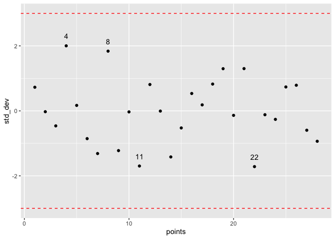

```r
ggplot(data = NULL, aes(x = points, y = std_dev)) +
     geom_point() +
     geom_text(aes(label = res_labels), nudge_y = 0.3) +
     geom_hline(yintercept = c(-3,3), colour = "red", linetype = "dashed")
```

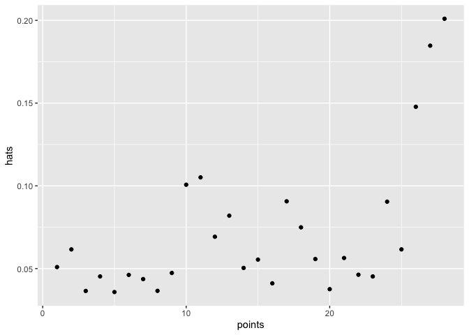

```r
hats <- hatvalues(qbinf)

ggplot(data = NULL, aes(x = points, y = hats))+
     geom_point()
```

There are three points at the end of the graph that on first glance you could have assumed they would be leverage points, but referencing the Y-Axis and the values are aprox 0.20 and below and therefore closer to 0 than 1, meaning there are no leverage points in this set of data.

## Influential Points

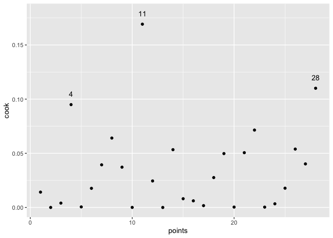

```r
cook <- cooks.distance(qbinf)

cook_labels <- if_else(cook >= 0.08, paste(points), "")

ggplot(data = NULL, aes(x = points, y = cook)) +
  geom_point() +
  geom_text(aes(label = cook_labels), nudge_y = 0.01)
```

```r
outliers <- c(4, 11, 28)
filtered_df <- filter_df %>%
  filter(case_no != "4",
         case_no != "11",
         case_no != "28")
```

### Regression With All Values

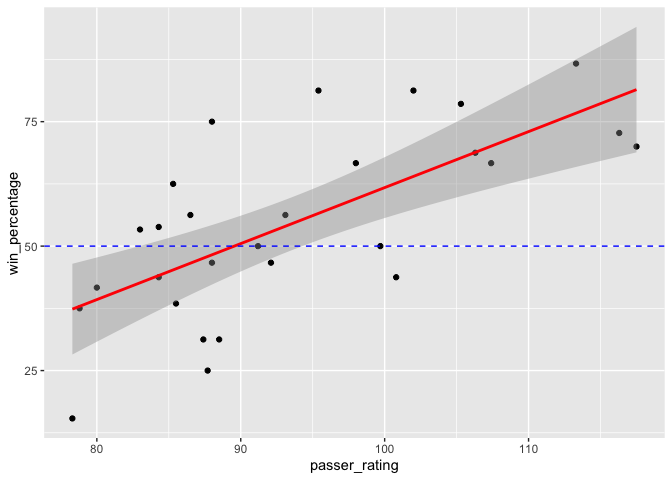

```r
ggplot(data = filter_df, aes(x = passer_rating, y = win_percentage)) +
  geom_point(colour = "black") +
  geom_smooth(method = "lm", colour = "red") +
  geom_hline(yintercept = 50, colour = "blue", linetype = "dashed")
```

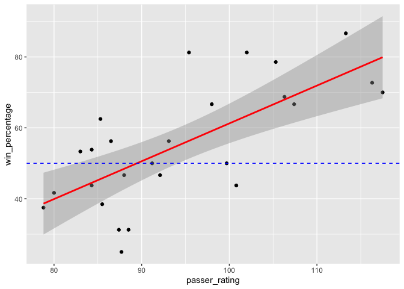

```r
ggplot(data = filtered_df, aes(x = passer_rating, y = win_percentage)) +
  geom_point(colour = "black") +
  geom_smooth(method = "lm", colour = "red") +
  geom_hline(yintercept = 50, colour = "blue", linetype = "dashed")
```

```r
cor(x = filtered_df$passer_rating, y = filtered_df$win_percentage, method = "pearson")
```

```
## [1] 0.7029611
```

```r
qbinf_lev <- lm(win_percentage ~ passer_rating, data = filtered_df)
tidy(qbinf, conf.int = TRUE)
```

```
## # A tibble: 2 x 7
##   term          estimate std.error statistic   p.value conf.low conf.high
##   <chr>            <dbl>     <dbl>     <dbl>     <dbl>    <dbl>     <dbl>
## 1 (Intercept)     -50.7     22.1       -2.30 0.0297     -96.1       -5.39
## 2 passer_rating     1.12     0.234      4.81 0.0000551    0.644      1.61
```

```r
summary(qbinf_lev)
```

```
##
## Call:
## lm(formula = win_percentage ~ passer_rating, data = filtered_df)
##
## Residuals:
##      Min       1Q   Median       3Q      Max
## -23.1277  -7.0281  -0.9414   9.3884  24.9074
##
## Coefficients:
##               Estimate Std. Error t value Pr(>|t|)
## (Intercept)   -45.4370    20.9678  -2.167   0.0404 *
## passer_rating   1.0669     0.2203   4.842 6.21e-05 ***
## ---
## Signif. codes:  0 '***' 0.001 '**' 0.01 '*' 0.05 '.' 0.1 ' ' 1
##
## Residual standard error: 12.34 on 24 degrees of freedom
## Multiple R-squared:  0.4942, Adjusted R-squared:  0.4731
## F-statistic: 23.45 on 1 and 24 DF,  p-value: 6.206e-05
```

## Homoscedasticity

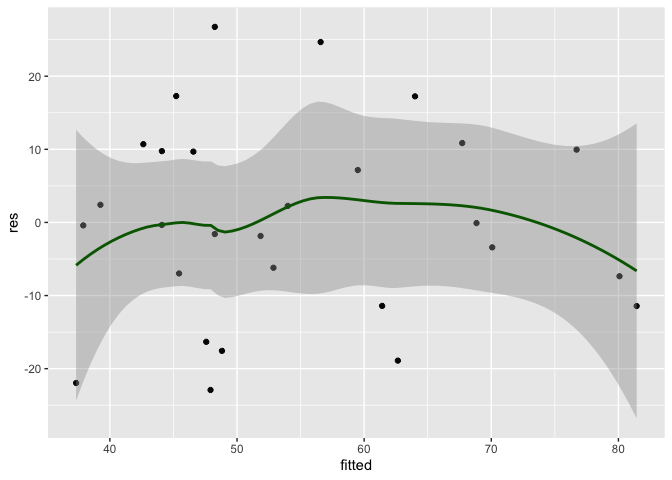

```r
res <- residuals(qbinf)
fitted <- predict(qbinf)

ggplot(data = NULL, aes( x = fitted, y = res)) +
     geom_point(colour = "grey2") +
     geom_smooth(colour = "darkgreen")
```

There’s minimal evidence shown above of heteroscedasticity.

## Normality of Residuals

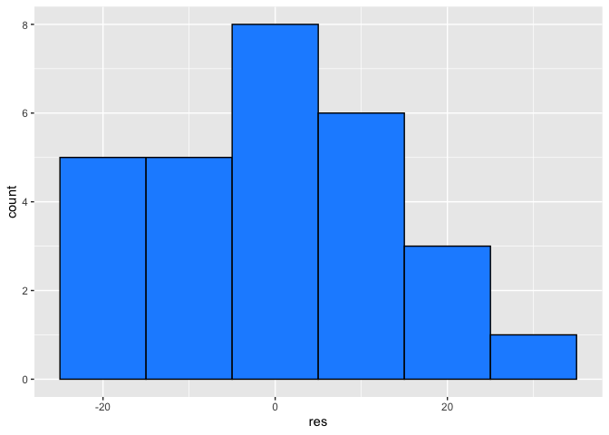

```r
ggplot(data = NULL, aes(x = res)) +
  geom_histogram(colour = "black", fill = "dodgerblue", binwidth = 10)
```

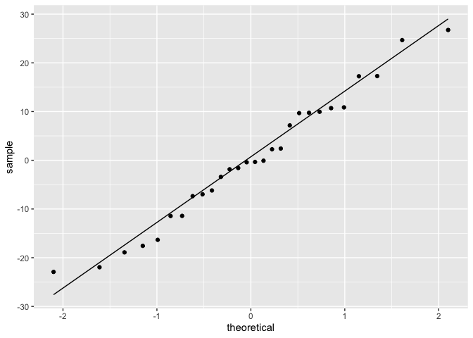

```r
ggplot(data = NULL, aes(sample = res)) +
     stat_qq() + stat_qq_line()
```

## Interpretation

Passing Rating alone, although it showed a linear relationship with the Winning Percentage, it was a weak relationship, which indicates that there are many more underlying factors at play rather than the passer rating. Yes, in NFL, the QB is the most important player, and with a poor QB, teams usually struggle to compete as they dictate the pace and style of the offence. The reason why it is a weak linear relationship though, is that there are multiple factors that can influence a game. For example, on offence, a lot of teams play a rushing yard style play, that doesn’t affect the QB’s passer rating positively or negatively. On top of that, if the defence is poor in their RB’s and LB’s the opposition QB’s passing game will be significantly strengthened as the risk of throwing pick 6’s are reduced as they have time to sit in the pocket and pick their ideal route. If a team’s defence gives up a lot of points, the QB passer rating won’t be the main influence of the winning percentage.